# Optimal Treatment Analysis

## Outcome Variable

**Outcome Variable:** whz

## Predictor Variables

**Intervention Variable:** predfeed36

**Adjustment Set:**

- arm
- sex
- month
- brthmon
- W_mage
- meducyrs
- feducyrs
- hhwealth_quart
- hfoodsec
- W_mhtcm
- vagbrth
- W_gagebrth
- W_birthwt
- W_birthlen
- W_nrooms
- W_nchldlt5
- W_parity
- impfloor
- impsan
- safeh20
- delta_W_mage
- delta_meducyrs
- delta_feducyrs
- delta_hhwealth_quart
- delta_hfoodsec
- delta_W_mhtcm
- delta_vagbrth
- delta_W_gagebrth
- delta_W_birthwt
- delta_W_birthlen
- delta_W_nrooms
- delta_W_nchldlt5
- delta_W_parity
- delta_impfloor
- delta_impsan
- delta_safeh20

## Stratifying Variables

The analysis was stratified on these variable(s):

- agecat
- studyid
- country

## Data Summary

| agecat | studyid | country | predfeed36 | n_cell | n |
| --- | --- | --- | --- | --- | --- |
| Birth | ki0047075b-MAL-ED | BANGLADESH | 1 | 120 | 230 |
| Birth | ki0047075b-MAL-ED | BANGLADESH | 0 | 110 | 230 |
| Birth | ki0047075b-MAL-ED | BRAZIL | 1 | 28 | 177 |
| Birth | ki0047075b-MAL-ED | BRAZIL | 0 | 149 | 177 |
| Birth | ki0047075b-MAL-ED | INDIA | 1 | 16 | 195 |
| Birth | ki0047075b-MAL-ED | INDIA | 0 | 179 | 195 |
| Birth | ki0047075b-MAL-ED | NEPAL | 1 | 25 | 167 |
| Birth | ki0047075b-MAL-ED | NEPAL | 0 | 142 | 167 |
| Birth | ki0047075b-MAL-ED | PERU | 1 | 116 | 266 |
| Birth | ki0047075b-MAL-ED | PERU | 0 | 150 | 266 |
| Birth | ki0047075b-MAL-ED | SOUTH AFRICA | 1 | 3 | 234 |
| Birth | ki0047075b-MAL-ED | SOUTH AFRICA | 0 | 231 | 234 |
| Birth | ki0047075b-MAL-ED | TANZANIA, UNITED REPUBLIC OF | 1 | 1 | 116 |
| Birth | ki0047075b-MAL-ED | TANZANIA, UNITED REPUBLIC OF | 0 | 115 | 116 |
| Birth | ki1000109-EE | PAKISTAN | 1 | 0 | 1 |
| Birth | ki1000109-EE | PAKISTAN | 0 | 1 | 1 |
| Birth | kiGH5241-JiVitA-3 | BANGLADESH | 1 | 9192 | 11319 |
| Birth | kiGH5241-JiVitA-3 | BANGLADESH | 0 | 2127 | 11319 |
| Birth | kiGH5241-JiVitA-4 | BANGLADESH | 1 | 493 | 602 |
| Birth | kiGH5241-JiVitA-4 | BANGLADESH | 0 | 109 | 602 |
| 6 months | ki0047075b-MAL-ED | BANGLADESH | 1 | 129 | 240 |
| 6 months | ki0047075b-MAL-ED | BANGLADESH | 0 | 111 | 240 |
| 6 months | ki0047075b-MAL-ED | BRAZIL | 1 | 37 | 209 |
| 6 months | ki0047075b-MAL-ED | BRAZIL | 0 | 172 | 209 |
| 6 months | ki0047075b-MAL-ED | INDIA | 1 | 19 | 236 |
| 6 months | ki0047075b-MAL-ED | INDIA | 0 | 217 | 236 |
| 6 months | ki0047075b-MAL-ED | NEPAL | 1 | 32 | 236 |
| 6 months | ki0047075b-MAL-ED | NEPAL | 0 | 204 | 236 |
| 6 months | ki0047075b-MAL-ED | PERU | 1 | 126 | 271 |
| 6 months | ki0047075b-MAL-ED | PERU | 0 | 145 | 271 |
| 6 months | ki0047075b-MAL-ED | SOUTH AFRICA | 1 | 3 | 254 |
| 6 months | ki0047075b-MAL-ED | SOUTH AFRICA | 0 | 251 | 254 |
| 6 months | ki0047075b-MAL-ED | TANZANIA, UNITED REPUBLIC OF | 1 | 2 | 247 |
| 6 months | ki0047075b-MAL-ED | TANZANIA, UNITED REPUBLIC OF | 0 | 245 | 247 |
| 6 months | ki1000109-EE | PAKISTAN | 1 | 224 | 371 |
| 6 months | ki1000109-EE | PAKISTAN | 0 | 147 | 371 |
| 6 months | ki1000304b-SAS-FoodSuppl | INDIA | 1 | 0 | 168 |
| 6 months | ki1000304b-SAS-FoodSuppl | INDIA | 0 | 168 | 168 |
| 6 months | ki1113344-GMS-Nepal | NEPAL | 1 | 423 | 526 |
| 6 months | ki1113344-GMS-Nepal | NEPAL | 0 | 103 | 526 |
| 6 months | ki1148112-LCNI-5 | MALAWI | 1 | 47 | 272 |
| 6 months | ki1148112-LCNI-5 | MALAWI | 0 | 225 | 272 |
| 6 months | kiGH5241-JiVitA-3 | BANGLADESH | 1 | 10674 | 13353 |
| 6 months | kiGH5241-JiVitA-3 | BANGLADESH | 0 | 2679 | 13353 |
| 6 months | kiGH5241-JiVitA-4 | BANGLADESH | 1 | 3255 | 4172 |
| 6 months | kiGH5241-JiVitA-4 | BANGLADESH | 0 | 917 | 4172 |
| 24 months | ki0047075b-MAL-ED | BANGLADESH | 1 | 117 | 211 |
| 24 months | ki0047075b-MAL-ED | BANGLADESH | 0 | 94 | 211 |
| 24 months | ki0047075b-MAL-ED | BRAZIL | 1 | 30 | 169 |
| 24 months | ki0047075b-MAL-ED | BRAZIL | 0 | 139 | 169 |
| 24 months | ki0047075b-MAL-ED | INDIA | 1 | 18 | 227 |
| 24 months | ki0047075b-MAL-ED | INDIA | 0 | 209 | 227 |
| 24 months | ki0047075b-MAL-ED | NEPAL | 1 | 30 | 228 |
| 24 months | ki0047075b-MAL-ED | NEPAL | 0 | 198 | 228 |
| 24 months | ki0047075b-MAL-ED | PERU | 1 | 94 | 200 |
| 24 months | ki0047075b-MAL-ED | PERU | 0 | 106 | 200 |
| 24 months | ki0047075b-MAL-ED | SOUTH AFRICA | 1 | 3 | 238 |
| 24 months | ki0047075b-MAL-ED | SOUTH AFRICA | 0 | 235 | 238 |
| 24 months | ki0047075b-MAL-ED | TANZANIA, UNITED REPUBLIC OF | 1 | 2 | 214 |
| 24 months | ki0047075b-MAL-ED | TANZANIA, UNITED REPUBLIC OF | 0 | 212 | 214 |
| 24 months | ki1113344-GMS-Nepal | NEPAL | 1 | 368 | 455 |
| 24 months | ki1113344-GMS-Nepal | NEPAL | 0 | 87 | 455 |
| 24 months | ki1148112-LCNI-5 | MALAWI | 1 | 34 | 184 |
| 24 months | ki1148112-LCNI-5 | MALAWI | 0 | 150 | 184 |
| 24 months | kiGH5241-JiVitA-3 | BANGLADESH | 1 | 5276 | 6672 |
| 24 months | kiGH5241-JiVitA-3 | BANGLADESH | 0 | 1396 | 6672 |
| 24 months | kiGH5241-JiVitA-4 | BANGLADESH | 1 | 3140 | 4009 |
| 24 months | kiGH5241-JiVitA-4 | BANGLADESH | 0 | 869 | 4009 |

The following strata were considered:

- agecat: 24 months, studyid: ki0047075b-MAL-ED, country: BANGLADESH
- agecat: 24 months, studyid: ki0047075b-MAL-ED, country: BRAZIL
- agecat: 24 months, studyid: ki0047075b-MAL-ED, country: INDIA
- agecat: 24 months, studyid: ki0047075b-MAL-ED, country: NEPAL
- agecat: 24 months, studyid: ki0047075b-MAL-ED, country: PERU
- agecat: 24 months, studyid: ki0047075b-MAL-ED, country: SOUTH AFRICA
- agecat: 24 months, studyid: ki0047075b-MAL-ED, country: TANZANIA, UNITED REPUBLIC OF
- agecat: 24 months, studyid: ki1113344-GMS-Nepal, country: NEPAL
- agecat: 24 months, studyid: ki1148112-LCNI-5, country: MALAWI
- agecat: 24 months, studyid: kiGH5241-JiVitA-3, country: BANGLADESH
- agecat: 24 months, studyid: kiGH5241-JiVitA-4, country: BANGLADESH
- agecat: 6 months, studyid: ki0047075b-MAL-ED, country: BANGLADESH
- agecat: 6 months, studyid: ki0047075b-MAL-ED, country: BRAZIL
- agecat: 6 months, studyid: ki0047075b-MAL-ED, country: INDIA
- agecat: 6 months, studyid: ki0047075b-MAL-ED, country: NEPAL
- agecat: 6 months, studyid: ki0047075b-MAL-ED, country: PERU
- agecat: 6 months, studyid: ki0047075b-MAL-ED, country: SOUTH AFRICA
- agecat: 6 months, studyid: ki0047075b-MAL-ED, country: TANZANIA, UNITED REPUBLIC OF
- agecat: 6 months, studyid: ki1000109-EE, country: PAKISTAN
- agecat: 6 months, studyid: ki1000304b-SAS-FoodSuppl, country: INDIA
- agecat: 6 months, studyid: ki1113344-GMS-Nepal, country: NEPAL
- agecat: 6 months, studyid: ki1148112-LCNI-5, country: MALAWI
- agecat: 6 months, studyid: kiGH5241-JiVitA-3, country: BANGLADESH
- agecat: 6 months, studyid: kiGH5241-JiVitA-4, country: BANGLADESH
- agecat: Birth, studyid: ki0047075b-MAL-ED, country: BANGLADESH
- agecat: Birth, studyid: ki0047075b-MAL-ED, country: BRAZIL
- agecat: Birth, studyid: ki0047075b-MAL-ED, country: INDIA
- agecat: Birth, studyid: ki0047075b-MAL-ED, country: NEPAL
- agecat: Birth, studyid: ki0047075b-MAL-ED, country: PERU
- agecat: Birth, studyid: ki0047075b-MAL-ED, country: SOUTH AFRICA
- agecat: Birth, studyid: ki0047075b-MAL-ED, country: TANZANIA, UNITED REPUBLIC OF
- agecat: Birth, studyid: ki1000109-EE, country: PAKISTAN
- agecat: Birth, studyid: kiGH5241-JiVitA-3, country: BANGLADESH
- agecat: Birth, studyid: kiGH5241-JiVitA-4, country: BANGLADESH

### Dropped Strata

Some strata were dropped due to rare outcomes:

- agecat: Birth, studyid: ki0047075b-MAL-ED, country: SOUTH AFRICA
- agecat: Birth, studyid: ki0047075b-MAL-ED, country: TANZANIA, UNITED REPUBLIC OF
- agecat: Birth, studyid: ki1000109-EE, country: PAKISTAN
- agecat: 6 months, studyid: ki0047075b-MAL-ED, country: SOUTH AFRICA
- agecat: 6 months, studyid: ki0047075b-MAL-ED, country: TANZANIA, UNITED REPUBLIC OF
- agecat: 6 months, studyid: ki1000304b-SAS-FoodSuppl, country: INDIA
- agecat: 24 months, studyid: ki0047075b-MAL-ED, country: SOUTH AFRICA
- agecat: 24 months, studyid: ki0047075b-MAL-ED, country: TANZANIA, UNITED REPUBLIC OF

## Methods Detail

We’re interested in the causal parameters $E[Y_a]$ for all values of $a \in \mathcal{A}$. These parameters represent the mean outcome if, possibly contrary to fact, we intervened to set all units to have $A=a$. Under the randomization and positivity assumptions, these are identified by the statistical parameters $\psi_a=E_W[E_{Y|A,W}(Y|A=a,W)]$. In addition, we’re interested in the mean of $Y$, $E[Y]$ under no intervention (the observed mean). We will estimate these parameters by using SuperLearner to fit the relevant likelihood factors – $E_{Y|A,W}(Y|A=a,W)$ and $p(A=a|W)$, and then updating our likelihood fit using a joint TMLE.

For unadjusted analyses ($W=\{\}$), initial likelihoods were estimated using Lrnr_glm to estimate the simple $E(Y|A)$ and Lrnr_mean to estimate $p(A)$. For adjusted analyses, a small library containing Lrnr_glmnet, Lrnr_xgboost, and Lrnr_mean was used.

# Results Detail

## Results Plots

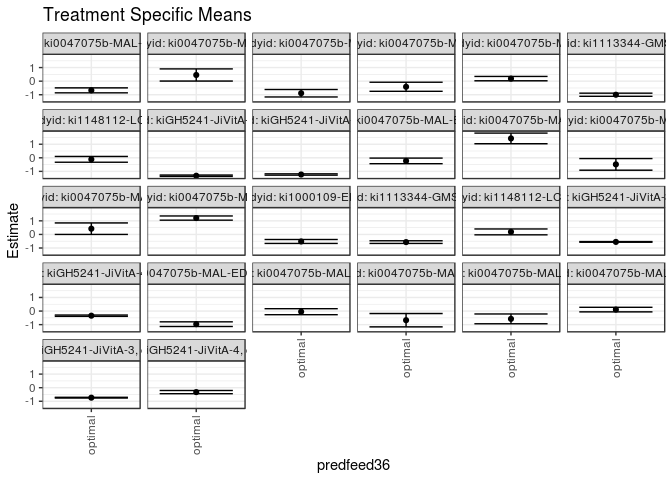

## Results Table

### Parameter: TSM

| agecat | studyid | country | intervention_level | baseline_level | estimate | ci_lower | ci_upper |
| --- | --- | --- | --- | --- | --- | --- | --- |
| Birth | ki0047075b-MAL-ED | BANGLADESH | optimal | observed | -0.9653920 | -1.1373687 | -0.7934153 |
| Birth | ki0047075b-MAL-ED | BRAZIL | optimal | observed | -0.0477386 | -0.2686243 | 0.1731470 |
| Birth | ki0047075b-MAL-ED | INDIA | optimal | observed | -0.6734089 | -1.1636727 | -0.1831450 |
| Birth | ki0047075b-MAL-ED | NEPAL | optimal | observed | -0.5741769 | -0.9357116 | -0.2126422 |
| Birth | ki0047075b-MAL-ED | PERU | optimal | observed | 0.1088658 | -0.0592821 | 0.2770137 |
| Birth | kiGH5241-JiVitA-3 | BANGLADESH | optimal | observed | -0.7353874 | -0.7600035 | -0.7107713 |
| Birth | kiGH5241-JiVitA-4 | BANGLADESH | optimal | observed | -0.3249538 | -0.4431309 | -0.2067766 |
| 6 months | ki0047075b-MAL-ED | BANGLADESH | optimal | observed | -0.2281066 | -0.4345502 | -0.0216629 |
| 6 months | ki0047075b-MAL-ED | BRAZIL | optimal | observed | 1.4273087 | 1.0362187 | 1.8183987 |
| 6 months | ki0047075b-MAL-ED | INDIA | optimal | observed | -0.4847377 | -0.9130717 | -0.0564037 |
| 6 months | ki0047075b-MAL-ED | NEPAL | optimal | observed | 0.4221552 | -0.0016697 | 0.8459801 |
| 6 months | ki0047075b-MAL-ED | PERU | optimal | observed | 1.2044482 | 1.0485125 | 1.3603839 |
| 6 months | ki1000109-EE | PAKISTAN | optimal | observed | -0.5192758 | -0.6638876 | -0.3746641 |
| 6 months | ki1113344-GMS-Nepal | NEPAL | optimal | observed | -0.5654142 | -0.6647660 | -0.4660625 |
| 6 months | ki1148112-LCNI-5 | MALAWI | optimal | observed | 0.1864795 | -0.0299044 | 0.4028635 |
| 6 months | kiGH5241-JiVitA-3 | BANGLADESH | optimal | observed | -0.5509577 | -0.5747187 | -0.5271968 |
| 6 months | kiGH5241-JiVitA-4 | BANGLADESH | optimal | observed | -0.3406899 | -0.3879458 | -0.2934340 |
| 24 months | ki0047075b-MAL-ED | BANGLADESH | optimal | observed | -0.6760822 | -0.8581289 | -0.4940356 |
| 24 months | ki0047075b-MAL-ED | BRAZIL | optimal | observed | 0.4538982 | 0.0066385 | 0.9011579 |
| 24 months | ki0047075b-MAL-ED | INDIA | optimal | observed | -0.8882518 | -1.1629689 | -0.6135347 |
| 24 months | ki0047075b-MAL-ED | NEPAL | optimal | observed | -0.4126631 | -0.7456453 | -0.0796810 |
| 24 months | ki0047075b-MAL-ED | PERU | optimal | observed | 0.1870428 | 0.0267484 | 0.3473373 |
| 24 months | ki1113344-GMS-Nepal | NEPAL | optimal | observed | -0.9994814 | -1.1152975 | -0.8836653 |
| 24 months | ki1148112-LCNI-5 | MALAWI | optimal | observed | -0.1137861 | -0.3258003 | 0.0982281 |
| 24 months | kiGH5241-JiVitA-3 | BANGLADESH | optimal | observed | -1.3208585 | -1.3704054 | -1.2713116 |
| 24 months | kiGH5241-JiVitA-4 | BANGLADESH | optimal | observed | -1.2303950 | -1.2787054 | -1.1820845 |

### Parameter: E(Y)

| agecat | studyid | country | intervention_level | baseline_level | estimate | ci_lower | ci_upper |
| --- | --- | --- | --- | --- | --- | --- | --- |
| Birth | ki0047075b-MAL-ED | BANGLADESH | observed | observed | -0.9773043 | -1.1153078 | -0.8393008 |
| Birth | ki0047075b-MAL-ED | BRAZIL | observed | observed | 0.3837288 | 0.2059602 | 0.5614974 |
| Birth | ki0047075b-MAL-ED | INDIA | observed | observed | -1.0816410 | -1.2241126 | -0.9391694 |
| Birth | ki0047075b-MAL-ED | NEPAL | observed | observed | -0.9126946 | -1.0520834 | -0.7733058 |
| Birth | ki0047075b-MAL-ED | PERU | observed | observed | -0.0602256 | -0.1729666 | 0.0525155 |
| Birth | kiGH5241-JiVitA-3 | BANGLADESH | observed | observed | -0.7445605 | -0.7677110 | -0.7214100 |
| Birth | kiGH5241-JiVitA-4 | BANGLADESH | observed | observed | -0.3861794 | -0.4712311 | -0.3011277 |
| 6 months | ki0047075b-MAL-ED | BANGLADESH | observed | observed | -0.1400243 | -0.2696346 | -0.0104140 |
| 6 months | ki0047075b-MAL-ED | BRAZIL | observed | observed | 0.9717225 | 0.8073791 | 1.1360658 |
| 6 months | ki0047075b-MAL-ED | INDIA | observed | observed | -0.7033969 | -0.8285284 | -0.5782654 |
| 6 months | ki0047075b-MAL-ED | NEPAL | observed | observed | 0.1110452 | -0.0202712 | 0.2423616 |
| 6 months | ki0047075b-MAL-ED | PERU | observed | observed | 1.0562362 | 0.9338834 | 1.1785889 |
| 6 months | ki1000109-EE | PAKISTAN | observed | observed | -0.7256065 | -0.8395859 | -0.6116270 |
| 6 months | ki1113344-GMS-Nepal | NEPAL | observed | observed | -0.6007161 | -0.6897580 | -0.5116742 |
| 6 months | ki1148112-LCNI-5 | MALAWI | observed | observed | 0.3927574 | 0.2737700 | 0.5117448 |
| 6 months | kiGH5241-JiVitA-3 | BANGLADESH | observed | observed | -0.5834618 | -0.6054534 | -0.5614701 |
| 6 months | kiGH5241-JiVitA-4 | BANGLADESH | observed | observed | -0.3973178 | -0.4385298 | -0.3561058 |
| 24 months | ki0047075b-MAL-ED | BANGLADESH | observed | observed | -0.8227962 | -0.9454140 | -0.7001785 |
| 24 months | ki0047075b-MAL-ED | BRAZIL | observed | observed | 0.4466272 | 0.2416144 | 0.6516401 |
| 24 months | ki0047075b-MAL-ED | INDIA | observed | observed | -0.9522907 | -1.0676596 | -0.8369219 |
| 24 months | ki0047075b-MAL-ED | NEPAL | observed | observed | -0.3764474 | -0.4898516 | -0.2630431 |
| 24 months | ki0047075b-MAL-ED | PERU | observed | observed | 0.1302000 | 0.0113848 | 0.2490152 |
| 24 months | ki1113344-GMS-Nepal | NEPAL | observed | observed | -1.1186923 | -1.2105469 | -1.0268377 |
| 24 months | ki1148112-LCNI-5 | MALAWI | observed | observed | -0.0771196 | -0.2204715 | 0.0662323 |
| 24 months | kiGH5241-JiVitA-3 | BANGLADESH | observed | observed | -1.3246418 | -1.3519597 | -1.2973238 |
| 24 months | kiGH5241-JiVitA-4 | BANGLADESH | observed | observed | -1.2418558 | -1.2769820 | -1.2067296 |

### Parameter: PAR

| agecat | studyid | country | intervention_level | baseline_level | estimate | ci_lower | ci_upper |
| --- | --- | --- | --- | --- | --- | --- | --- |
| Birth | ki0047075b-MAL-ED | BANGLADESH | optimal | observed | -0.0119123 | -0.1494954 | 0.1256708 |
| Birth | ki0047075b-MAL-ED | BRAZIL | optimal | observed | 0.4314674 | 0.2409257 | 0.6220092 |
| Birth | ki0047075b-MAL-ED | INDIA | optimal | observed | -0.4082322 | -0.8820424 | 0.0655780 |
| Birth | ki0047075b-MAL-ED | NEPAL | optimal | observed | -0.3385177 | -0.6741234 | -0.0029119 |
| Birth | ki0047075b-MAL-ED | PERU | optimal | observed | -0.1690913 | -0.2884527 | -0.0497300 |
| Birth | kiGH5241-JiVitA-3 | BANGLADESH | optimal | observed | -0.0091731 | -0.0186681 | 0.0003219 |
| Birth | kiGH5241-JiVitA-4 | BANGLADESH | optimal | observed | -0.0612256 | -0.1670017 | 0.0445504 |
| 6 months | ki0047075b-MAL-ED | BANGLADESH | optimal | observed | 0.0880823 | -0.0438249 | 0.2199895 |
| 6 months | ki0047075b-MAL-ED | BRAZIL | optimal | observed | -0.4555862 | -0.8130360 | -0.0981364 |
| 6 months | ki0047075b-MAL-ED | INDIA | optimal | observed | -0.2186592 | -0.6359303 | 0.1986119 |
| 6 months | ki0047075b-MAL-ED | NEPAL | optimal | observed | -0.3111100 | -0.7011224 | 0.0789025 |
| 6 months | ki0047075b-MAL-ED | PERU | optimal | observed | -0.1482120 | -0.2762171 | -0.0202069 |
| 6 months | ki1000109-EE | PAKISTAN | optimal | observed | -0.2063306 | -0.3078520 | -0.1048093 |
| 6 months | ki1113344-GMS-Nepal | NEPAL | optimal | observed | -0.0353019 | -0.0794710 | 0.0088673 |
| 6 months | ki1148112-LCNI-5 | MALAWI | optimal | observed | 0.2062778 | 0.0320877 | 0.3804680 |
| 6 months | kiGH5241-JiVitA-3 | BANGLADESH | optimal | observed | -0.0325040 | -0.0427141 | -0.0222940 |
| 6 months | kiGH5241-JiVitA-4 | BANGLADESH | optimal | observed | -0.0566280 | -0.0772772 | -0.0359787 |
| 24 months | ki0047075b-MAL-ED | BANGLADESH | optimal | observed | -0.1467140 | -0.2860003 | -0.0074277 |
| 24 months | ki0047075b-MAL-ED | BRAZIL | optimal | observed | -0.0072710 | -0.3944608 | 0.3799188 |
| 24 months | ki0047075b-MAL-ED | INDIA | optimal | observed | -0.0640390 | -0.3345026 | 0.2064247 |
| 24 months | ki0047075b-MAL-ED | NEPAL | optimal | observed | 0.0362158 | -0.2712820 | 0.3437135 |
| 24 months | ki0047075b-MAL-ED | PERU | optimal | observed | -0.0568428 | -0.1766284 | 0.0629427 |
| 24 months | ki1113344-GMS-Nepal | NEPAL | optimal | observed | -0.1192109 | -0.2007367 | -0.0376851 |
| 24 months | ki1148112-LCNI-5 | MALAWI | optimal | observed | 0.0366665 | -0.1148262 | 0.1881593 |
| 24 months | kiGH5241-JiVitA-3 | BANGLADESH | optimal | observed | -0.0037833 | -0.0475098 | 0.0399432 |
| 24 months | kiGH5241-JiVitA-4 | BANGLADESH | optimal | observed | -0.0114608 | -0.0444160 | 0.0214943 |